# 1. Description

## 1.1 Background and Context

You are a Data Scientist for a tourism company named "Visit with us". The Policy Maker of the company wants to enable and establish a viable business model to expand the customer base.

A viable business model is a central concept that helps you to understand the existing ways of doing the business and how to change the ways for the benefit of the tourism sector.

One of the ways to expand the customer base is to introduce a new offering of packages.

Currently, there are 5 types of packages the company is offering - Basic, Standard, Deluxe, Super Deluxe, King. Looking at the data of the last year, we observed that 18% of the customers purchased the packages.

However, the marketing cost was quite high because customers were contacted at random without looking at the available information.

The company is now planning to launch a new product i.e. Wellness Tourism Package. Wellness Tourism is defined as Travel that allows the traveler to maintain, enhance or kick-start a healthy lifestyle, and support or increase one's sense of well-being.

However, this time company wants to harness the available data of existing and potential customers to make the marketing expenditure more efficient.

You as a Data Scientist at "Visit with us" travel company have to analyze the customers' data and information to provide recommendations to the Policy Maker and Marketing Team and also build a model to predict the potential customer who is going to purchase the newly introduced travel package.

## 1.2 Objective

To predict which customer is more likely to purchase the newly introduced travel package.

## 1.3 Data Dictionary

### 1.3.1 Customer details:

CustomerID: Unique customer ID ProdTaken: Whether the customer has purchased a package or not (0: No, 1: Yes)

Age: Age of customer

TypeofContact: How customer was contacted (Company Invited or Self Inquiry)

CityTier: City tier depends on the development of a city, population, facilities, and living standards. The categories are ordered i.e. Tier 1 > Tier 2 > Tier 3

Occupation: Occupation of customer

Gender: Gender of customer

NumberOfPersonVisiting: Total number of persons planning to take the trip with the customer

PreferredPropertyStar: Preferred hotel property rating by customer

MaritalStatus: Marital status of customer

NumberOfTrips: Average number of trips in a year by customer

Passport: The customer has a passport or not (0: No, 1: Yes)

OwnCar: Whether the customers own a car or not (0: No, 1: Yes)

NumberOfChildrenVisiting: Total number of children with age less than 5 planning to take the trip with the customer

Designation: Designation of the customer in the current organization

MonthlyIncome: Gross monthly income of the customer

### 1.3.2 Customer interaction data:

PitchSatisfactionScore: Sales pitch satisfaction score

ProductPitched: Product pitched by the salesperson

NumberOfFollowups: Total number of follow-ups has been done by the salesperson after the sales pitch

DurationOfPitch: Duration of the pitch by a salesperson to the customer

# 2. Data Import & Analysis

## 2.1 Import libraries

```python
import numpy as np
import pandas as pd
import matplotlib.pyplot as plt
import seaborn as sns
from sklearn.tree import DecisionTreeClassifier
from sklearn.model_selection import train_test_split
from sklearn.metrics import confusion_matrix, classification_report
from sklearn.metrics import accuracy_score,precision_score,recall_score,f1_score
import scipy.stats as stats
from sklearn import metrics
from sklearn import tree
from sklearn.model_selection import GridSearchCV
from sklearn.ensemble import BaggingClassifier
from sklearn.ensemble import RandomForestClassifier
from sklearn.ensemble import AdaBoostClassifier, GradientBoostingClassifier
from xgboost import XGBClassifier
from sklearn.model_selection import GridSearchCV
from sklearn.ensemble import StackingClassifier
import warnings
warnings.filterwarnings('ignore')
```

## 2.2 Read data

```python
# Store the dataset in a Pandas dataframe - tourism
tourism = pd.read_excel("Tourism.xlsx", sheet_name='Tourism')
```

## 2.3 View the first and last 5 rows of the dataset.

```python
tourism.head()
```

|  | CustomerID | ProdTaken | Age | TypeofContact | CityTier | DurationOfPitch | Occupation | Gender | NumberOfPersonVisiting | NumberOfFollowups | ProductPitched | PreferredPropertyStar | MaritalStatus | NumberOfTrips | Passport | PitchSatisfactionScore | OwnCar | NumberOfChildrenVisiting | Designation | MonthlyIncome |
| --- | --- | --- | --- | --- | --- | --- | --- | --- | --- | --- | --- | --- | --- | --- | --- | --- | --- | --- | --- | --- |
| 0 | 200000 | 1 | 41.0 | Self Enquiry | 3 | 6.0 | Salaried | Female | 3 | 3.0 | Deluxe | 3.0 | Single | 1.0 | 1 | 2 | 1 | 0.0 | Manager | 20993.0 |
| 1 | 200001 | 0 | 49.0 | Company Invited | 1 | 14.0 | Salaried | Male | 3 | 4.0 | Deluxe | 4.0 | Divorced | 2.0 | 0 | 3 | 1 | 2.0 | Manager | 20130.0 |
| 2 | 200002 | 1 | 37.0 | Self Enquiry | 1 | 8.0 | Free Lancer | Male | 3 | 4.0 | Basic | 3.0 | Single | 7.0 | 1 | 3 | 0 | 0.0 | Executive | 17090.0 |
| 3 | 200003 | 0 | 33.0 | Company Invited | 1 | 9.0 | Salaried | Female | 2 | 3.0 | Basic | 3.0 | Divorced | 2.0 | 1 | 5 | 1 | 1.0 | Executive | 17909.0 |
| 4 | 200004 | 0 | NaN | Self Enquiry | 1 | 8.0 | Small Business | Male | 2 | 3.0 | Basic | 4.0 | Divorced | 1.0 | 0 | 5 | 1 | 0.0 | Executive | 18468.0 |

```python
tourism.tail()
```

|  | CustomerID | ProdTaken | Age | TypeofContact | CityTier | DurationOfPitch | Occupation | Gender | NumberOfPersonVisiting | NumberOfFollowups | ProductPitched | PreferredPropertyStar | MaritalStatus | NumberOfTrips | Passport | PitchSatisfactionScore | OwnCar | NumberOfChildrenVisiting | Designation | MonthlyIncome |
| --- | --- | --- | --- | --- | --- | --- | --- | --- | --- | --- | --- | --- | --- | --- | --- | --- | --- | --- | --- | --- |
| 4883 | 204883 | 1 | 49.0 | Self Enquiry | 3 | 9.0 | Small Business | Male | 3 | 5.0 | Deluxe | 4.0 | Unmarried | 2.0 | 1 | 1 | 1 | 1.0 | Manager | 26576.0 |
| 4884 | 204884 | 1 | 28.0 | Company Invited | 1 | 31.0 | Salaried | Male | 4 | 5.0 | Basic | 3.0 | Single | 3.0 | 1 | 3 | 1 | 2.0 | Executive | 21212.0 |
| 4885 | 204885 | 1 | 52.0 | Self Enquiry | 3 | 17.0 | Salaried | Female | 4 | 4.0 | Standard | 4.0 | Married | 7.0 | 0 | 1 | 1 | 3.0 | Senior Manager | 31820.0 |
| 4886 | 204886 | 1 | 19.0 | Self Enquiry | 3 | 16.0 | Small Business | Male | 3 | 4.0 | Basic | 3.0 | Single | 3.0 | 0 | 5 | 0 | 2.0 | Executive | 20289.0 |
| 4887 | 204887 | 1 | 36.0 | Self Enquiry | 1 | 14.0 | Salaried | Male | 4 | 4.0 | Basic | 4.0 | Unmarried | 3.0 | 1 | 3 | 1 | 2.0 | Executive | 24041.0 |

## 2.4 Understand shape of the data

```python
tourism.shape
```

```
(4888, 20)
```

The dataset has 4888 rows and 20 columns of data

## 2.5 Check the data types of the columns for the dataset

```python
tourism.info()
```

```
<class 'pandas.core.frame.DataFrame'>
RangeIndex: 4888 entries, 0 to 4887
Data columns (total 20 columns):
 #   Column                    Non-Null Count  Dtype
---  ------                    --------------  -----
 0   CustomerID                4888 non-null   int64
 1   ProdTaken                 4888 non-null   int64
 2   Age                       4662 non-null   float64
 3   TypeofContact             4863 non-null   object
 4   CityTier                  4888 non-null   int64
 5   DurationOfPitch           4637 non-null   float64
 6   Occupation                4888 non-null   object
 7   Gender                    4888 non-null   object
 8   NumberOfPersonVisiting    4888 non-null   int64
 9   NumberOfFollowups         4843 non-null   float64
 10  ProductPitched            4888 non-null   object
 11  PreferredPropertyStar     4862 non-null   float64
 12  MaritalStatus             4888 non-null   object
 13  NumberOfTrips             4748 non-null   float64
 14  Passport                  4888 non-null   int64
 15  PitchSatisfactionScore    4888 non-null   int64
 16  OwnCar                    4888 non-null   int64
 17  NumberOfChildrenVisiting  4822 non-null   float64
 18  Designation               4888 non-null   object
 19  MonthlyIncome             4655 non-null   float64
dtypes: float64(7), int64(7), object(6)
memory usage: 763.9+ KB
```

### Observations:

```python
# Lets drop missing values
tourism.dropna(inplace=True)
```

```python
# Let's check if the missing values were actually dropped
tourism.info()
```

```
<class 'pandas.core.frame.DataFrame'>
Int64Index: 4128 entries, 0 to 4887
Data columns (total 20 columns):
 #   Column                    Non-Null Count  Dtype
---  ------                    --------------  -----
 0   CustomerID                4128 non-null   int64
 1   ProdTaken                 4128 non-null   int64
 2   Age                       4128 non-null   float64
 3   TypeofContact             4128 non-null   object
 4   CityTier                  4128 non-null   int64
 5   DurationOfPitch           4128 non-null   float64
 6   Occupation                4128 non-null   object
 7   Gender                    4128 non-null   object
 8   NumberOfPersonVisiting    4128 non-null   int64
 9   NumberOfFollowups         4128 non-null   float64
 10  ProductPitched            4128 non-null   object
 11  PreferredPropertyStar     4128 non-null   float64
 12  MaritalStatus             4128 non-null   object
 13  NumberOfTrips             4128 non-null   float64
 14  Passport                  4128 non-null   int64
 15  PitchSatisfactionScore    4128 non-null   int64
 16  OwnCar                    4128 non-null   int64
 17  NumberOfChildrenVisiting  4128 non-null   float64
 18  Designation               4128 non-null   object
 19  MonthlyIncome             4128 non-null   float64
dtypes: float64(7), int64(7), object(6)
memory usage: 677.2+ KB
```

## 2.6 Fixing dataset and data types

### 2.6.1 Check for categorical coding errors and fix them

#### Let's see the unique values for each of the variables that need to be converted in to categorical type. This will also let's us see if there are coding errors - such as "Fe Male" vs "Female"

```python
tourism.Passport.unique()
```

```
array([1, 0], dtype=int64)
```

```python
tourism.CityTier.unique()
```

```
array([3, 1, 2], dtype=int64)
```

```python
tourism.TypeofContact.unique()
```

```
array(['Self Enquiry', 'Company Invited'], dtype=object)
```

```python
tourism.Occupation.unique()
```

```
array(['Salaried', 'Free Lancer', 'Small Business', 'Large Business'],
      dtype=object)
```

```python
tourism.Gender.unique()
```

```
array(['Female', 'Male', 'Fe Male'], dtype=object)
```

```python
tourism.loc[(tourism.Gender == 'Fe Male'),'Gender']='Female'
```

```python
tourism.Gender.unique()
```

```
array(['Female', 'Male'], dtype=object)
```

```python
tourism.ProductPitched.unique()
```

```
array(['Deluxe', 'Basic', 'Standard', 'Super Deluxe', 'King'],
      dtype=object)
```

```python
tourism.MaritalStatus.unique()
```

```
array(['Single', 'Divorced', 'Married', 'Unmarried'], dtype=object)
```

```python
tourism.Designation.unique()
```

```
array(['Manager', 'Executive', 'Senior Manager', 'AVP', 'VP'],
      dtype=object)
```

### 2.6.2 Convert int64s to categories

The following variables are captured as int64 - but they relly are categorical in nature.

They need to be converted into categorial before data analysis

```python
tourism['OwnCar'] = tourism['OwnCar'].astype('category')
```

```python
tourism['CityTier'] = tourism['CityTier'].astype('category')
```

```python
tourism['Passport'] = tourism['Passport'].astype('category')
```

```python
tourism['ProdTaken'] = tourism['ProdTaken'].astype('category')
```

### 2.6.3 Convert objects to categories

The following variables are captured as object - but they relly are categorical in nature.

They need to be converted into categorial before data analysis

```python
cols = tourism.select_dtypes([object])
cols.columns
```

```
Index(['TypeofContact', 'Occupation', 'Gender', 'ProductPitched',
       'MaritalStatus', 'Designation'],
      dtype='object')
```

```python
for i in cols.columns:
    tourism[i] = tourism[i].astype('category')
```

#### Sanity Check: Lets check if our changes to data types were affected in the data set

```python
tourism.info()
```

```
<class 'pandas.core.frame.DataFrame'>
Int64Index: 4128 entries, 0 to 4887
Data columns (total 20 columns):
 #   Column                    Non-Null Count  Dtype
---  ------                    --------------  -----
 0   CustomerID                4128 non-null   int64
 1   ProdTaken                 4128 non-null   category
 2   Age                       4128 non-null   float64
 3   TypeofContact             4128 non-null   category
 4   CityTier                  4128 non-null   category
 5   DurationOfPitch           4128 non-null   float64
 6   Occupation                4128 non-null   category
 7   Gender                    4128 non-null   category
 8   NumberOfPersonVisiting    4128 non-null   int64
 9   NumberOfFollowups         4128 non-null   float64
 10  ProductPitched            4128 non-null   category
 11  PreferredPropertyStar     4128 non-null   float64
 12  MaritalStatus             4128 non-null   category
 13  NumberOfTrips             4128 non-null   float64
 14  Passport                  4128 non-null   category
 15  PitchSatisfactionScore    4128 non-null   int64
 16  OwnCar                    4128 non-null   category
 17  NumberOfChildrenVisiting  4128 non-null   float64
 18  Designation               4128 non-null   category
 19  MonthlyIncome             4128 non-null   float64
dtypes: category(10), float64(7), int64(3)
memory usage: 396.4 KB
```

### 2.6.4 Summary of dataset

```python
tourism.describe()
```

|  | CustomerID | Age | DurationOfPitch | NumberOfPersonVisiting | NumberOfFollowups | PreferredPropertyStar | NumberOfTrips | PitchSatisfactionScore | NumberOfChildrenVisiting | MonthlyIncome |
| --- | --- | --- | --- | --- | --- | --- | --- | --- | --- | --- |
| count | 4128.000000 | 4128.000000 | 4128.000000 | 4128.000000 | 4128.000000 | 4128.000000 | 4128.0000 | 4128.000000 | 4128.000000 | 4128.000000 |
| mean | 202527.763808 | 37.231831 | 15.584787 | 2.949370 | 3.741521 | 3.578488 | 3.2953 | 3.060804 | 1.223595 | 23178.464147 |
| std | 1409.439133 | 9.174521 | 8.398142 | 0.718818 | 1.006786 | 0.795031 | 1.8563 | 1.363064 | 0.852685 | 4506.614622 |
| min | 200000.000000 | 18.000000 | 5.000000 | 1.000000 | 1.000000 | 3.000000 | 1.0000 | 1.000000 | 0.000000 | 1000.000000 |
| 25% | 201320.750000 | 31.000000 | 9.000000 | 2.000000 | 3.000000 | 3.000000 | 2.0000 | 2.000000 | 1.000000 | 20751.000000 |
| 50% | 202603.500000 | 36.000000 | 14.000000 | 3.000000 | 4.000000 | 3.000000 | 3.0000 | 3.000000 | 1.000000 | 22418.000000 |
| 75% | 203748.250000 | 43.000000 | 20.000000 | 3.000000 | 4.000000 | 4.000000 | 4.0000 | 4.000000 | 2.000000 | 25301.000000 |
| max | 204887.000000 | 61.000000 | 127.000000 | 5.000000 | 6.000000 | 5.000000 | 22.0000 | 5.000000 | 3.000000 | 98678.000000 |

#### Observations on numerical variables

1) CustomerID is an ID and not useful - it can be removed

2) Age ranges from 18 to 61 and average is 37

3) There are some extreme values in DurationOfPitch (127 mins)

4) There are soem extreme values in NumberOfTrips (22)

```python
tourism.describe(include=['category']).T
```

|  | count | unique | top | freq |
| --- | --- | --- | --- | --- |
| ProdTaken | 4128 | 2 | 0 | 3331 |
| TypeofContact | 4128 | 2 | Self Enquiry | 2918 |
| CityTier | 4128 | 3 | 1 | 2678 |
| Occupation | 4128 | 4 | Salaried | 1999 |
| Gender | 4128 | 2 | Male | 2463 |
| ProductPitched | 4128 | 5 | Basic | 1615 |
| MaritalStatus | 4128 | 4 | Married | 1990 |
| Passport | 4128 | 2 | 0 | 2909 |
| OwnCar | 4128 | 2 | 1 | 2527 |
| Designation | 4128 | 5 | Executive | 1615 |

#### Observations on categorical variables:

1) Most surveyed - did not take the product pitched - about 3331 out 4128 in the cleaned data set

```python
tourism.head()
```

|  | CustomerID | ProdTaken | Age | TypeofContact | CityTier | DurationOfPitch | Occupation | Gender | NumberOfPersonVisiting | NumberOfFollowups | ProductPitched | PreferredPropertyStar | MaritalStatus | NumberOfTrips | Passport | PitchSatisfactionScore | OwnCar | NumberOfChildrenVisiting | Designation | MonthlyIncome |
| --- | --- | --- | --- | --- | --- | --- | --- | --- | --- | --- | --- | --- | --- | --- | --- | --- | --- | --- | --- | --- |
| 0 | 200000 | 1 | 41.0 | Self Enquiry | 3 | 6.0 | Salaried | Female | 3 | 3.0 | Deluxe | 3.0 | Single | 1.0 | 1 | 2 | 1 | 0.0 | Manager | 20993.0 |
| 1 | 200001 | 0 | 49.0 | Company Invited | 1 | 14.0 | Salaried | Male | 3 | 4.0 | Deluxe | 4.0 | Divorced | 2.0 | 0 | 3 | 1 | 2.0 | Manager | 20130.0 |
| 2 | 200002 | 1 | 37.0 | Self Enquiry | 1 | 8.0 | Free Lancer | Male | 3 | 4.0 | Basic | 3.0 | Single | 7.0 | 1 | 3 | 0 | 0.0 | Executive | 17090.0 |
| 3 | 200003 | 0 | 33.0 | Company Invited | 1 | 9.0 | Salaried | Female | 2 | 3.0 | Basic | 3.0 | Divorced | 2.0 | 1 | 5 | 1 | 1.0 | Executive | 17909.0 |
| 5 | 200005 | 0 | 32.0 | Company Invited | 1 | 8.0 | Salaried | Male | 3 | 3.0 | Basic | 3.0 | Single | 1.0 | 0 | 5 | 1 | 1.0 | Executive | 18068.0 |

### 2.6.6 Drop columns that dont add value

```python
tourism = tourism.drop(['CustomerID'], axis=1)
```

# 3. EDA

## 3.1 Univariate Analysis

```python
# While doing uni-variate analysis of numerical variables we want to study their central tendency
# and dispersion.
# Let us write a function that will help us create boxplot and histogram for any input numerical
# variable.
# This function takes the numerical column as the input and returns the boxplots
# and histograms for the variable.
# Let us see if this help us write faster and cleaner code.
def histogram_boxplot(feature, figsize=(15,10), bins = None):
    """ Boxplot and histogram combined
    feature: 1-d feature array
    figsize: size of fig (default (9,8))
    bins: number of bins (default None / auto)
    """
    f2, (ax_box2, ax_hist2) = plt.subplots(nrows = 2, # Number of rows of the subplot grid= 2
                                           sharex = True, # x-axis will be shared among all subplots
                                           gridspec_kw = {"height_ratios": (.25, .75)},
                                           figsize = figsize
                                           ) # creating the 2 subplots
    sns.boxplot(feature, ax=ax_box2, showmeans=True, color='violet') # boxplot will be created and a star will indicate the mean value of the column
    sns.distplot(feature, kde=F, ax=ax_hist2, bins=bins,palette="winter") if bins else sns.distplot(feature, kde=False, ax=ax_hist2) # For histogram
    ax_hist2.axvline(np.mean(feature), color='green', linestyle='--') # Add mean to the histogram
    ax_hist2.axvline(np.median(feature), color='black', linestyle='-') # Add median to the histogram
```

### 3.1.1 Age

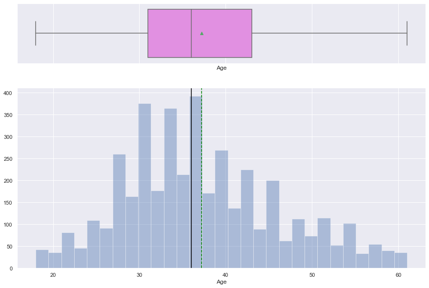

```python
histogram_boxplot(tourism['Age'])
```

### Observations:

Age is approximately normally distributed and there are no outliers

### 3.1.2 DurationOfPitch

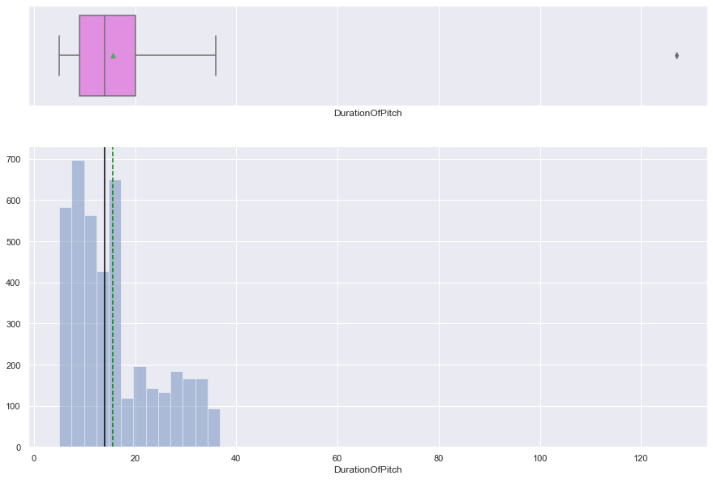

```python
histogram_boxplot(tourism['DurationOfPitch'])
```

### Observations:

1. There is one outlier - which needs to be fixed

### 3.1.3 NumberOfPersonVisiting

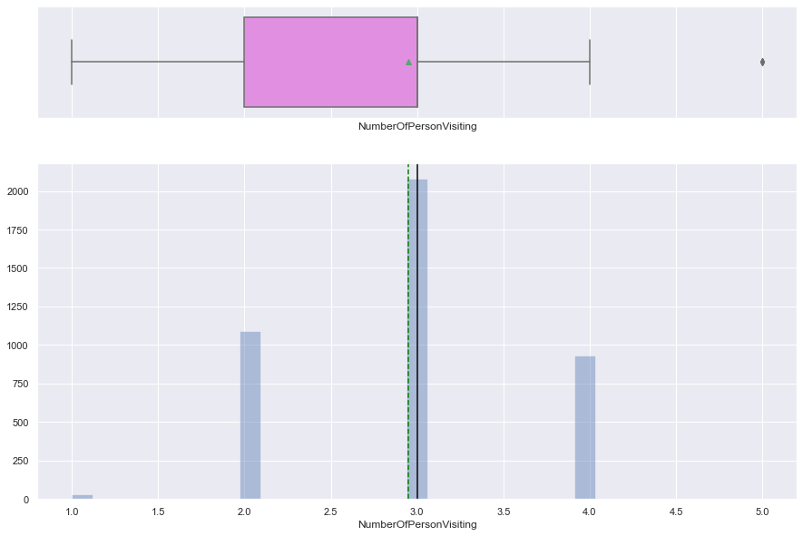

```python
histogram_boxplot(tourism['NumberOfPersonVisiting'])
```

### Observations:

1. There is one outlier - which needs to be fixed

### 3.1.4 NumberOfFollowups

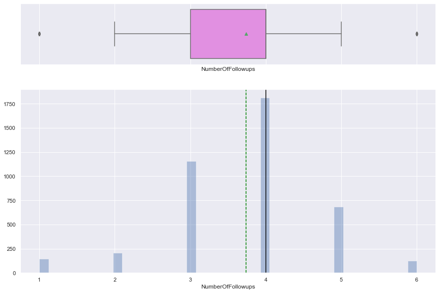

```python
histogram_boxplot(tourism['NumberOfFollowups'])
```

### 3.1.5 PreferredPropertyStar

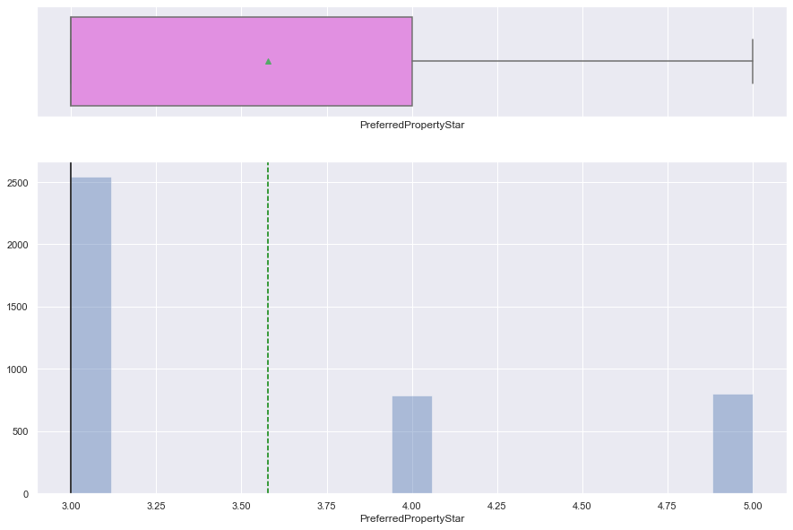

```python
histogram_boxplot(tourism['PreferredPropertyStar'])
```

### 3.1.6 NumberOfTrips

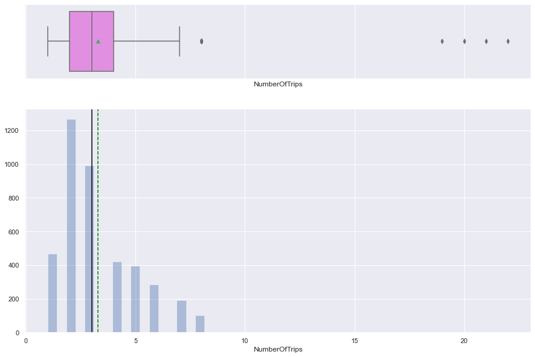

```python
histogram_boxplot(tourism['NumberOfTrips'])
```

### Observations:

1. There is one 5 outliers - which needs to be fixed
2. Data is right skewed normal distribution

### 3.1.7 PitchSatisfactionScore

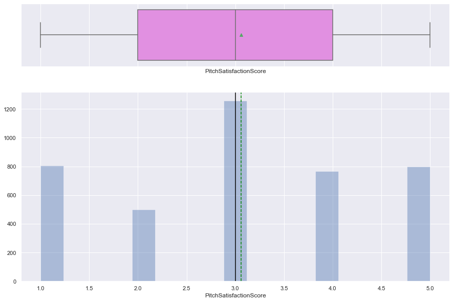

```python
histogram_boxplot(tourism['PitchSatisfactionScore'])
```

### 3.1.8 NumberOfChildrenVisiting

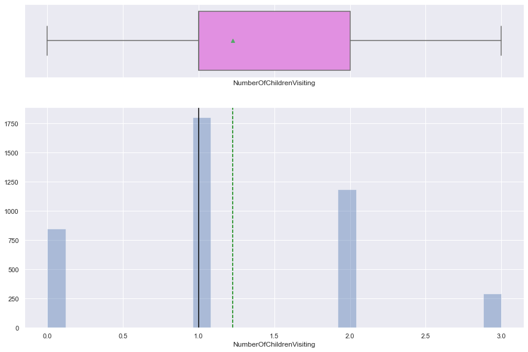

```python
histogram_boxplot(tourism['NumberOfChildrenVisiting'])
```

### Observations:

1. Appears to be a normally distributed data set

### 3.1.9 MonthlyIncome

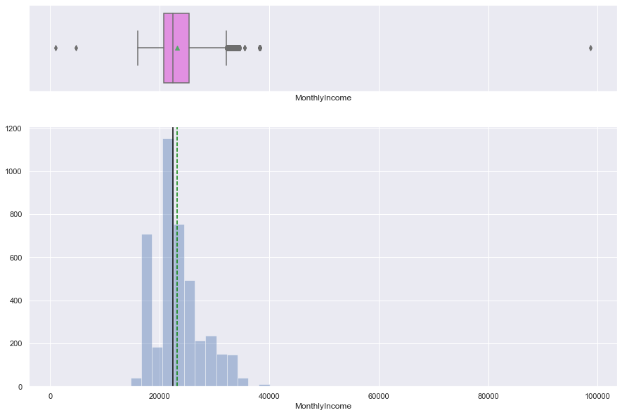

```python
histogram_boxplot(tourism['MonthlyIncome'])
```

### Observations:

1. There are outliers in both sides of the distribution - which needs to be fixed

## 3.2 Categorical variables

```python
# Code to plot categorical variables
# Function to create barplots that indicate percentage for each category.

def perc_on_bar(plot, feature):
    '''
    plot
    feature: categorical feature
    the function won't work if a column is passed in hue parameter
    '''

    total = len(feature) # length of the column
    for p in ax.patches:
        percentage = '{:.1f}%'.format(100 * p.get_height()/total) # percentage of each class of the category
        x = p.get_x() + p.get_width() / 2 - 0.05 # width of the plot
        y = p.get_y() + p.get_height()           # hieght of the plot
        ax.annotate(percentage, (x, y), size = 12) # annotate the percantage

    plt.show() # show the plot
```

### 3.2.1 TypeOfContact

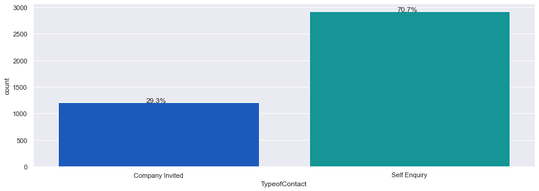

```python
plt.figure(figsize=(15,5))
ax = sns.countplot(tourism["TypeofContact"],palette='winter')
perc_on_bar(ax,tourism["TypeofContact"])
```

#### Observations

1. More customers self enquired about the vacation packages than the company reached out as part of marketing campaign

### 3.2.2 CityTier

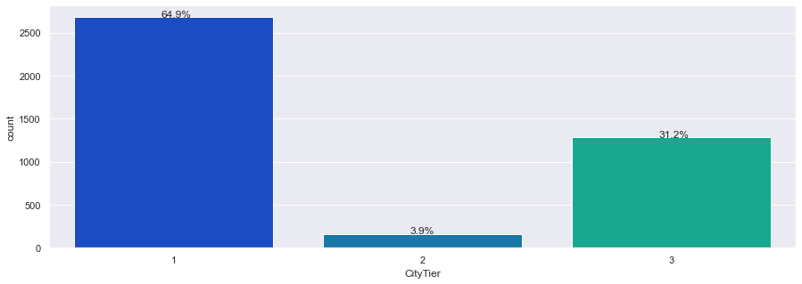

```python
plt.figure(figsize=(15,5))
ax = sns.countplot(tourism["CityTier"],palette='winter')
perc_on_bar(ax,tourism["CityTier"])
```

#### Observations

1. More participants where from higher tier cities
2. More than 95% of the respondents either belonged to a top tier or a bottom tier city - with very few in the middle

### 3.2.2 Occupation

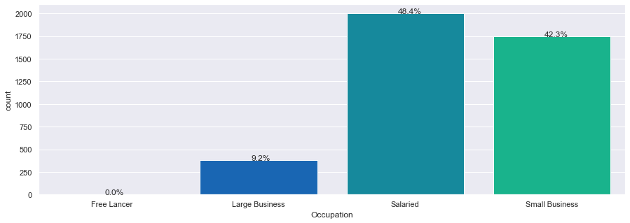

```python
plt.figure(figsize=(15,5))
ax = sns.countplot(tourism["Occupation"],palette='winter')
perc_on_bar(ax,tourism["Occupation"])
```

#### Observations

1. Majority of respondents were Salaried professionals
2. About an equal numnber were small business owners
3. Only a small portion were large businesses
4. This is a useful information for Marketing to have when running future campaigns

### 3.2.3 Gender

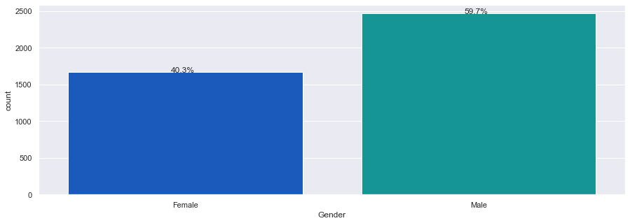

```python
plt.figure(figsize=(15,5))
ax = sns.countplot(tourism["Gender"],palette='winter')
perc_on_bar(ax,tourism["Gender"])
```

#### Observations

1. Majority of respodents were males

### 3.2.3 ProductPitched

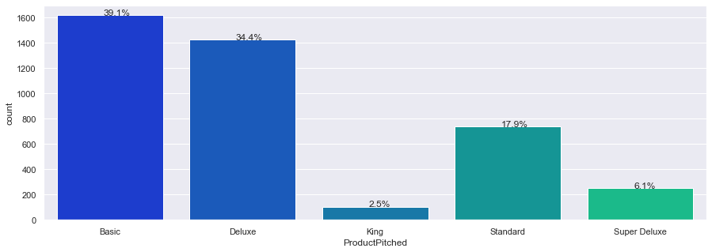

```python
plt.figure(figsize=(15,5))
ax = sns.countplot(tourism["ProductPitched"],palette='winter')
perc_on_bar(ax,tourism["ProductPitched"])
```

#### Observations

1. It appears that more expensive packages wer pitched less than cheaper packages

### 3.2.4 MaritalStatus

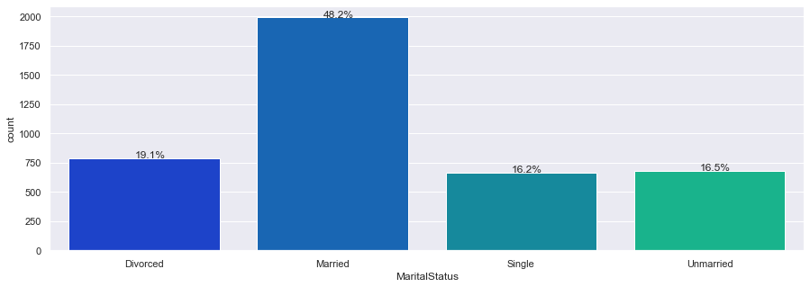

```python
plt.figure(figsize=(15,5))
ax = sns.countplot(tourism["MaritalStatus"],palette='winter')
perc_on_bar(ax,tourism["MaritalStatus"])
```

#### Observations

1. Majority of respondents were married.

### 3.2.4 Passport

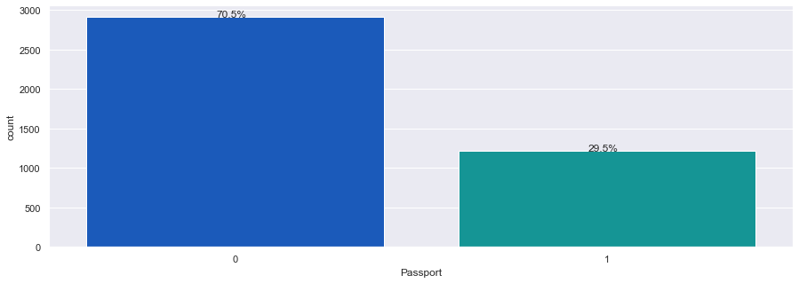

```python
plt.figure(figsize=(15,5))
ax = sns.countplot(tourism["Passport"],palette='winter')
perc_on_bar(ax,tourism["Passport"])
```

### 3.2.5 OwnCar

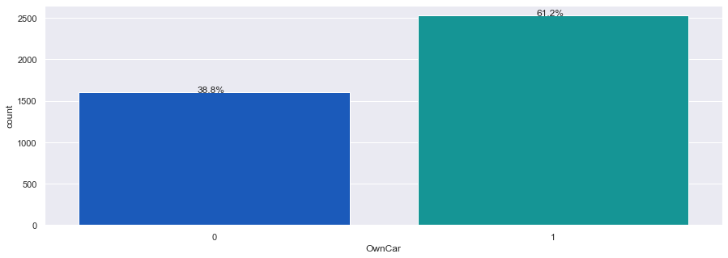

```python
plt.figure(figsize=(15,5))
ax = sns.countplot(tourism["OwnCar"],palette='winter')
perc_on_bar(ax,tourism["OwnCar"])
```

#### Observations

1. More than 60% of respondents owned a car which can be a good indication of economic well being

### 3.2.6 Designation

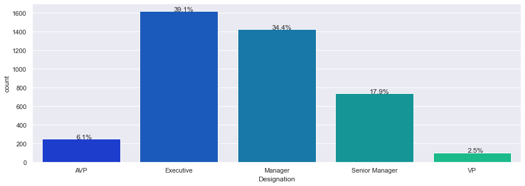

```python
plt.figure(figsize=(15,5))
ax = sns.countplot(tourism["Designation"],palette='winter')
perc_on_bar(ax,tourism["Designation"])
```

#### Observations

1. Majority of respondents were in a a management position (higher than or equal to manager designation)

## 3.4 Bi-variate analysis

### 3.4.1 Correlation Matrix

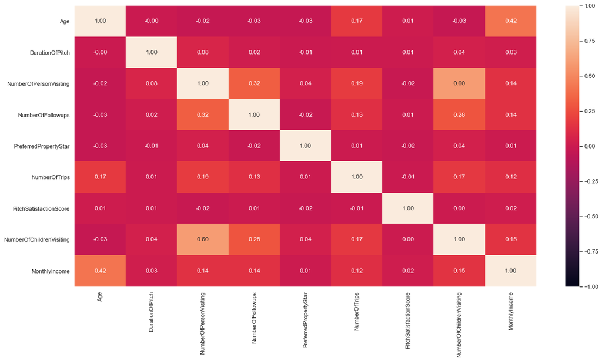

```python
plt.figure(figsize=(20,10))
sns.heatmap(tourism.corr(),annot=True,vmin=-1,vmax=1,fmt='.2f')
plt.show()
```

### Observations

1. There arent many variables that are closely correlated
2. Unsuirprisingly - Number of Childrean visiting and Number of person visiting are correlated - but not very strongly
3. Overall - there is no reason to drop any variables at this point

### 3.4.2 Helper Plotting Functions

```python
### Function to plot stacked bar charts for categorical columns
def stacked_plot(x):
    sns.set()
    ## crosstab
    tab1 = pd.crosstab(x,tourism['ProdTaken'],margins=True).sort_values(by=1,ascending=False)
    print(tab1)
    print('-'*120)
    ## visualising the cross tab
    tab = pd.crosstab(x,tourism['ProdTaken'],normalize='index').sort_values(by=1,ascending=False)
    tab.plot(kind='bar',stacked=True,figsize=(17,7))
    plt.legend(loc='lower left', frameon=False,)
    plt.legend(loc="upper left", bbox_to_anchor=(1,1))
    plt.show()
```

### 3.4.3 ProdTaken vs TypeofContact

```
ProdTaken           0    1   All
TypeofContact
All              3331  797  4128
Self Enquiry     2396  522  2918
Company Invited   935  275  1210
------------------------------------------------------------------------------------------------------------------------
```

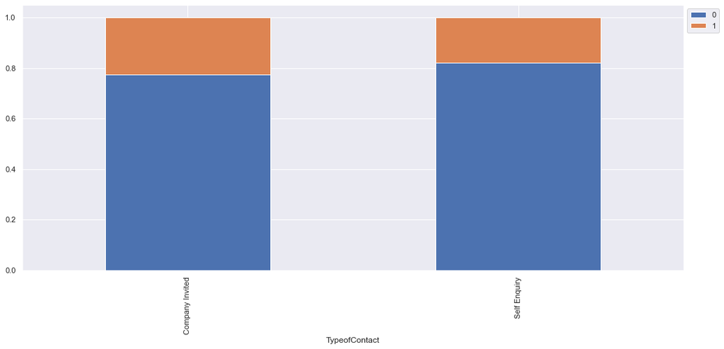

```python
stacked_plot(tourism['TypeofContact'])
```

#### Observations

1. Among the two sets of people - self enquired and company invited - the success rate for buying a package seems to be roughly identical with a cmall advantage to Company invited people

### 3.4.4 ProdTaken vs CityTier

```
ProdTaken     0    1   All
CityTier
All        3331  797  4128
1          2235  443  2678
3           977  311  1288
2           119   43   162
------------------------------------------------------------------------------------------------------------------------
```

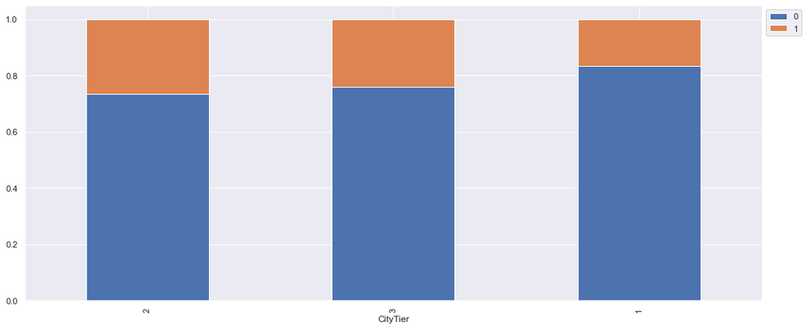

```python
stacked_plot(tourism['CityTier'])
```

#### Observations

1. Surprisingly - lower tier cities have a higher rate of success with accepting package

### 3.4.5 ProdTaken vs Occupation

```
ProdTaken          0    1   All
Occupation
All             3331  797  4128
Salaried        1640  359  1999
Small Business  1421  325  1746
Large Business   270  111   381
Free Lancer        0    2     2
------------------------------------------------------------------------------------------------------------------------
```

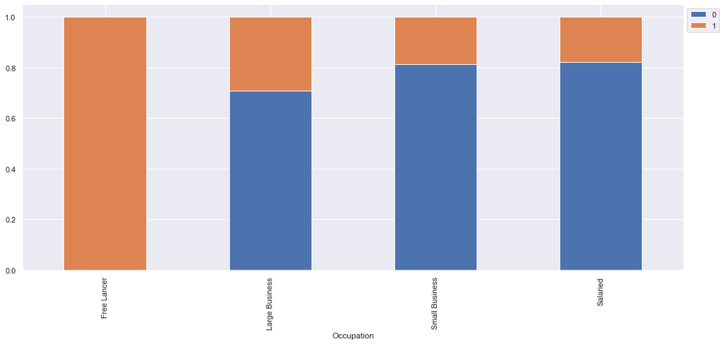

```python
stacked_plot(tourism['Occupation'])
```

#### Observations

1. Freerlancers have a 100% success rate - which is not surprising af they control their time commitment at work and have better cointrol over dispensable time and money

```
ProdTaken     0    1   All
Gender
All        3331  797  4128
Male       1965  498  2463
Female     1366  299  1665
------------------------------------------------------------------------------------------------------------------------
```

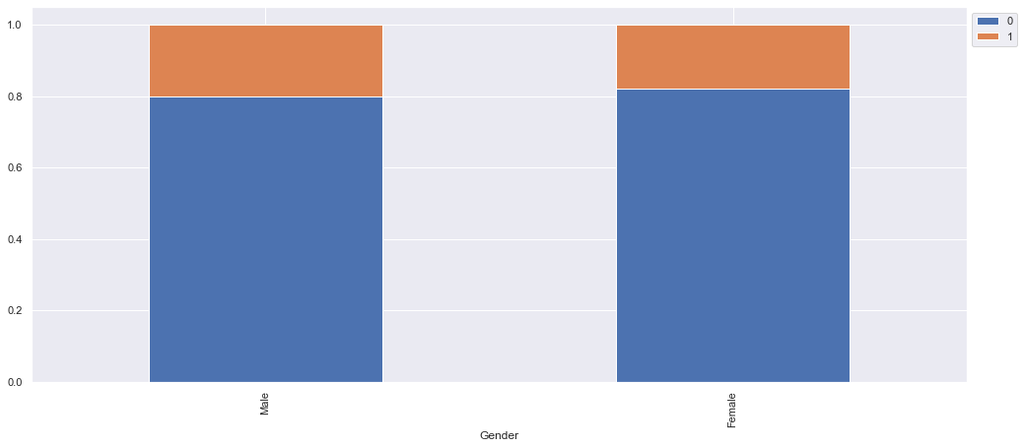

```python
stacked_plot(tourism['Gender'])
```

#### Observations

1. Success rate of selling a package seems to be gender neutral in this data set

### 3.4.7 ProdTaken vs ProductPitched

```
ProdTaken          0    1   All
ProductPitched
All             3331  797  4128
Basic           1130  485  1615
Deluxe          1257  165  1422
Standard         618  119   737
Super Deluxe     231   19   250
King              95    9   104
------------------------------------------------------------------------------------------------------------------------
```

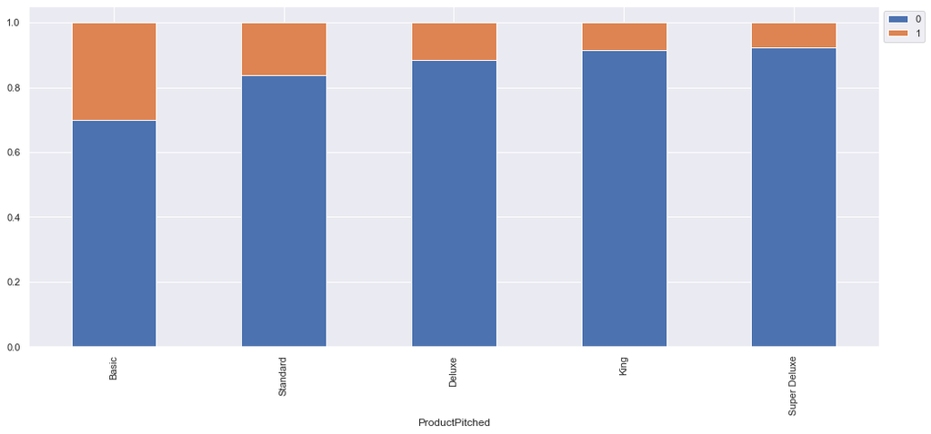

```python
stacked_plot(tourism['ProductPitched'])
```

#### Observations

1. Success rate of selling a package dips with increasing cost of the package.
2. Basic package has the best selling rate and Super Delux package has the lowest selling rate

### 3.4.8 ProdTaken vs MaritalStatus

```
ProdTaken         0    1   All
MaritalStatus
All            3331  797  4128
Married        1707  283  1990
Single          424  243   667
Unmarried       516  166   682
Divorced        684  105   789
------------------------------------------------------------------------------------------------------------------------
```

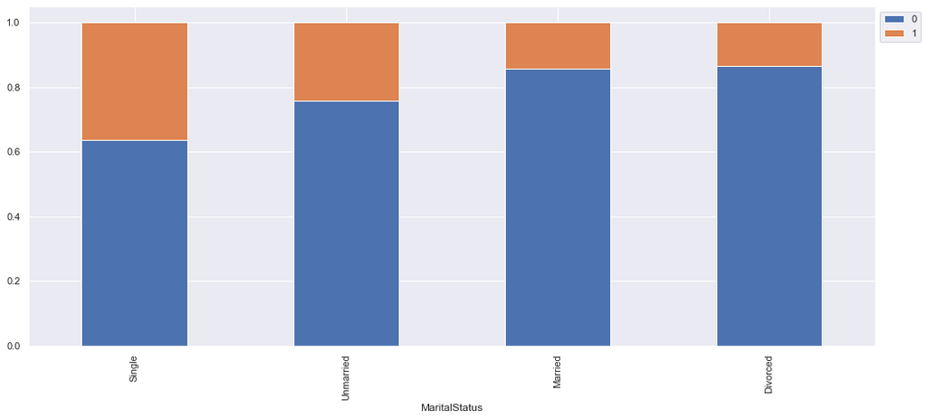

```python
stacked_plot(tourism['MaritalStatus'])
```

### 3.4.9 ProdTaken vs Passport

```
ProdTaken     0    1   All
Passport
All        3331  797  4128
1           782  437  1219
0          2549  360  2909
------------------------------------------------------------------------------------------------------------------------
```

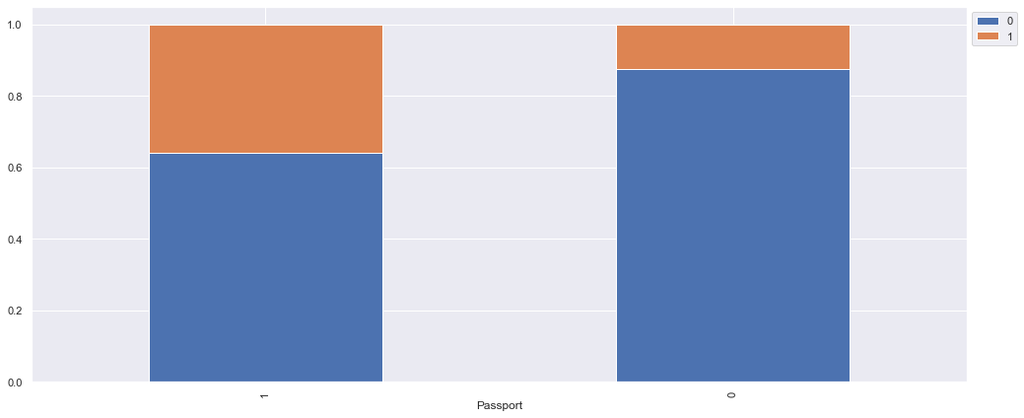

```python
stacked_plot(tourism['Passport'])
```

#### Observations

1. Those who have passport are more likel to travel

### 3.4.10 ProdTaken vs OwnCar

```
ProdTaken     0    1   All
OwnCar
All        3331  797  4128
1          2046  481  2527
0          1285  316  1601
------------------------------------------------------------------------------------------------------------------------
```

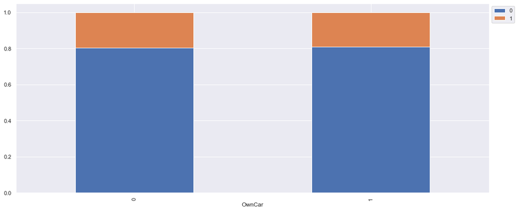

```python
stacked_plot(tourism['OwnCar'])
```

#### Observations:

1. Car ownership doesnt seem to affect the package purchase in a univariate sense

### 3.4.11 ProdTaken vs Designation

```
ProdTaken          0    1   All
Designation
All             3331  797  4128
Executive       1130  485  1615
Manager         1257  165  1422
Senior Manager   618  119   737
AVP              231   19   250
VP                95    9   104
------------------------------------------------------------------------------------------------------------------------
```

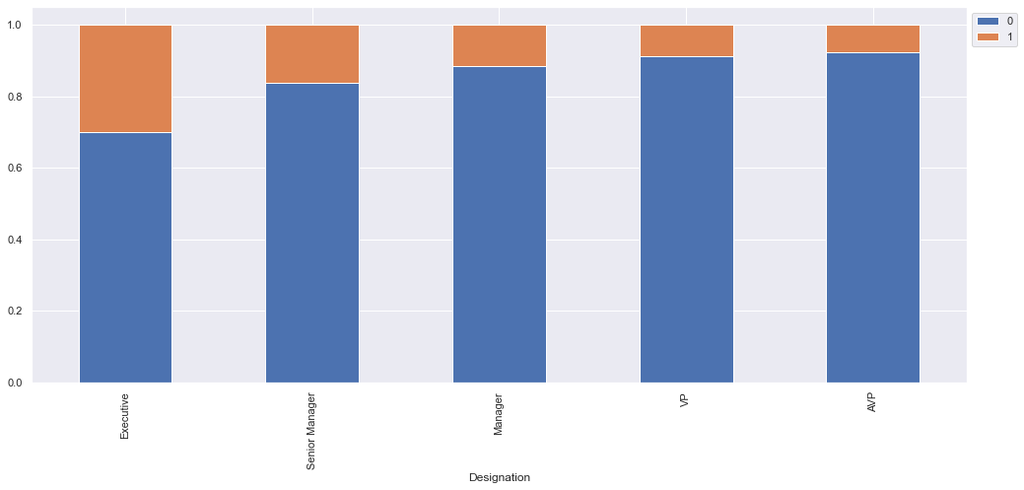

```python
stacked_plot(tourism['Designation'])
```

## 3.5 Data pre-processing & preparation

### 3.5.1 Treat outliers

```python
# Helper function to treat outliers
# Lets treat outliers by flooring and capping

def treat_outliers(df,col):
    '''
    treats outliers in a varaible
    col: str, name of the numerical varaible
    df: data frame
    col: name of the column
    '''
    Q1=df[col].quantile(0.25) # 25th quantile
    Q3=df[col].quantile(0.75)  # 75th quantile
    IQR=Q3-Q1
    Lower_Whisker = Q1 - 1.5*IQR
    Upper_Whisker = Q3 + 1.5*IQR
    df[col] = np.clip(df[col], Lower_Whisker, Upper_Whisker) # all the values samller than Lower_Whisker will be assigned value of Lower_whisker
                                                            # and all the values above upper_whishker will be assigned value of upper_Whisker
    return df

def treat_outliers_all(df, col_list):
    '''
    treat outlier in all numerical varaibles
    col_list: list of numerical varaibles
    df: data frame
    '''
    for c in col_list:
        df = treat_outliers(df,c)

    return df
```

```python
# Form a list of columns that have outliers and need to be treated

outlier_cols = ['DurationOfPitch','NumberOfPersonVisiting','NumberOfFollowups','NumberOfTrips','MonthlyIncome']

tourism = treat_outliers_all(tourism, outlier_cols)
```

### 3.5.2 Splitting Data into Training and Test sets

```python
X = tourism.drop(['ProdTaken'],axis=1)
X = pd.get_dummies(X,drop_first=True)
y = tourism['ProdTaken']
feature_names = list(X.columns)
```

```python
# Splitting data into training and test set:
X_train, X_test, y_train, y_test =train_test_split(X, y, test_size=0.3, random_state=1,stratify=y)
print(X_train.shape, X_test.shape)
```

```
(2889, 29) (1239, 29)
```

```python
# Check for weights of the dependent variable
y.value_counts(1)
```

```
0    0.806928
1    0.193072
Name: ProdTaken, dtype: float64
```

```python
# Check for weights of the dependent variable
y_test.value_counts(1)
```

```
0    0.807103
1    0.192897
Name: ProdTaken, dtype: float64
```

# 4. Bagging Model Building

## 4.1 Model evaluation criteria

### Wrong predictions are:

1. Predicting a person will buy package - but they dont (False Positive)
2. Predicting a person will not buy package - but they do (False Negative)

Our goal is to minimize the error or incorrectly predicting a purchase of package (#1). This is a Type 1 error. We are not too worried about #2 (Type 2 error) as we assume that the only cost associated with this error is the time spent by marketing in trying to convince a person who doesnt buy.

### Choice of metric

1. Our first choice of metric is Precision
2. Our second choice of metric will be F1 score

#### Helper functions to calculate metrics

```python
def make_confusion_matrix(model,y_actual,labels=[1, 0]):
    '''
    model : classifier to predict values of X
    y_actual : ground truth

    '''
    y_predict = model.predict(X_test)
    cm=metrics.confusion_matrix( y_actual, y_predict, labels=[0, 1])
    df_cm = pd.DataFrame(cm, index = [i for i in ["Actual - No","Actual - Yes"]],
                  columns = [i for i in ['Predicted - No','Predicted - Yes']])
    group_counts = ["{0:0.0f}".format(value) for value in
                cm.flatten()]
    group_percentages = ["{0:.2%}".format(value) for value in
                         cm.flatten()/np.sum(cm)]
    labels = [f"{v1}\n{v2}" for v1, v2 in
              zip(group_counts,group_percentages)]
    labels = np.asarray(labels).reshape(2,2)
    plt.figure(figsize = (10,7))
    sns.heatmap(df_cm, annot=labels,fmt='')
    plt.ylabel('True label')
    plt.xlabel('Predicted label')
```

```python
##  Function to calculate different metric scores of the model - Accuracy, Recall and Precision
def get_metrics_score(model,flag=True):
    '''
    model : classifier to predict values of X

    '''
    # defining an empty list to store train and test results
    score_list=[]

    pred_train = model.predict(X_train)
    pred_test = model.predict(X_test)

    train_acc = model.score(X_train,y_train)
    test_acc = model.score(X_test,y_test)

    train_recall = metrics.recall_score(y_train,pred_train)
    test_recall = metrics.recall_score(y_test,pred_test)

    train_precision = metrics.precision_score(y_train,pred_train)
    test_precision = metrics.precision_score(y_test,pred_test)

    train_f1 = f1_score(y_train,pred_train)
    test_f1 = f1_score(y_test,pred_test)

    score_list.extend((train_acc,test_acc,train_recall,test_recall,train_precision,test_precision, train_f1, test_f1))

    # If the flag is set to True then only the following print statements will be dispayed. The default value is set to True.
    if flag == True:
        print("Accuracy on training set : ",model.score(X_train,y_train))
        print("Accuracy on test set : ",model.score(X_test,y_test))
        print("Recall on training set : ",metrics.recall_score(y_train,pred_train))
        print("Recall on test set : ",metrics.recall_score(y_test,pred_test))
        print("Precision on training set : ",metrics.precision_score(y_train,pred_train))
        print("Precision on test set : ",metrics.precision_score(y_test,pred_test))
        print("F1-Score on training set : ",metrics.f1_score(y_train,pred_train))
        print("F1-Score on test set : ",metrics.f1_score(y_test,pred_test))

    return score_list # returning the list with train and test scores
```

## 4.2 Build Normal Decision Tree

#### Let's build a normal decision tree with weighted classes as the basis for the analyusis

```python
# Bild a decision tree
dtree = DecisionTreeClassifier(criterion='gini',class_weight={0:0.80,1:0.20},random_state=1)
```

```python
dtree.fit(X_train, y_train)
```

```
DecisionTreeClassifier(class_weight={0: 0.8, 1: 0.2}, random_state=1)
```

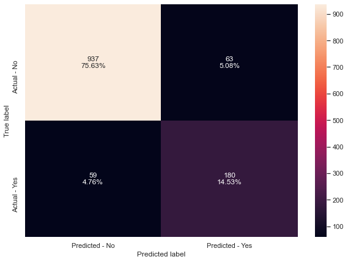

```python
# Create confusion matrix
make_confusion_matrix(dtree,y_test)
```

```python
# Create metrics
get_metrics_score(dtree)
```

```
Accuracy on training set :  1.0
Accuracy on test set :  0.9015334947538337
Recall on training set :  1.0
Recall on test set :  0.7531380753138075
Precision on training set :  1.0
Precision on test set :  0.7407407407407407
F1-Score on training set :  1.0
F1-Score on test set :  0.7468879668049792
```

```
[1.0,
 0.9015334947538337,
 1.0,
 0.7531380753138075,
 1.0,
 0.7407407407407407,
 1.0,
 0.7468879668049792]
```

#### * The decision tree is overfitting all metrics including precision

## 4.3 Build a Tuned Decision Tree

#### Let's tune hyper parameters of the decision tree for better results

```python
# Choose the type of classifier.
dtree_estimator = DecisionTreeClassifier(class_weight={0:0.80,1:0.20},random_state=1)

# Grid of parameters to choose from
parameters = {'max_depth': np.arange(2,30),
              'min_samples_leaf': [1, 2, 5, 7, 10],
              'max_leaf_nodes' : [2, 3, 5, 10,15],
              'min_impurity_decrease': [0.0001,0.001,0.01,0.1]
             }

# Type of scoring used to compare parameter combinations
scorer = metrics.make_scorer(metrics.precision_score)

# Run the grid search
grid_obj = GridSearchCV(dtree_estimator, parameters, scoring=scorer)
grid_obj = grid_obj.fit(X_train, y_train)

# Set the clf to the best combination of parameters
dtree_estimator = grid_obj.best_estimator_

# Fit the best algorithm to the data.
dtree_estimator.fit(X_train, y_train)
```

```
DecisionTreeClassifier(class_weight={0: 0.8, 1: 0.2}, max_depth=4,
                       max_leaf_nodes=10, min_impurity_decrease=0.0001,
                       random_state=1)
```

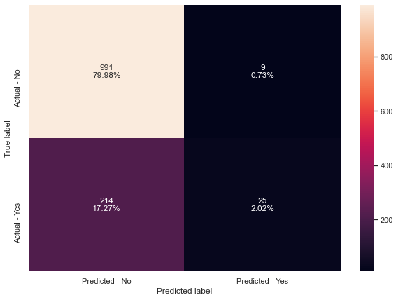

```python
make_confusion_matrix(dtree_estimator,y_test)
```

```python
get_metrics_score(dtree_estimator)
```

```
Accuracy on training set :  0.8283142956040153
Accuracy on test set :  0.8200161420500404
Recall on training set :  0.11827956989247312
Recall on test set :  0.10460251046025104
Precision on training set :  0.9428571428571428
Precision on test set :  0.7352941176470589
F1-Score on training set :  0.21019108280254775
F1-Score on test set :  0.18315018315018314
```

```
[0.8283142956040153,
 0.8200161420500404,
 0.11827956989247312,
 0.10460251046025104,
 0.9428571428571428,
 0.7352941176470589,
 0.21019108280254775,
 0.18315018315018314]
```

#### * This tree is performing well on precision but poorly on recall. This leads to a very poor F1 score

## 4.4 Bagging Classifier

```python
# Let's extend the BagingClassifier to include importance - the standard BaggingClassifier
# does not include importance feature.
# Source: https://stackoverflow.com/questions/44333573/feature-importances-bagging-scikit-learn

class BaggingClassifierCoefs(BaggingClassifier):
    def __init__(self,**kwargs):
        super().__init__(**kwargs)
        # add attribute of interest
        self.feature_importances_ = None
    def fit(self, X, y, sample_weight=None):
        # overload fit function to compute feature_importance
        fitted = self._fit(X, y, self.max_samples, sample_weight=sample_weight) # hidden fit function
        if hasattr(fitted.estimators_[0], 'feature_importances_'):
            self.feature_importances_ =  np.mean([tree.feature_importances_ for tree in fitted.estimators_], axis=0)
        else:
            self.feature_importances_ =  np.mean([tree.coef_ for tree in fitted.estimators_], axis=0)
            return(fitted)
```

```python
# bagging = BaggingClassifier(random_state=1)
bagging = BaggingClassifierCoefs(base_estimator=DecisionTreeClassifier(criterion='gini',random_state=1),random_state=1)
bagging.fit(X_train,y_train)
```

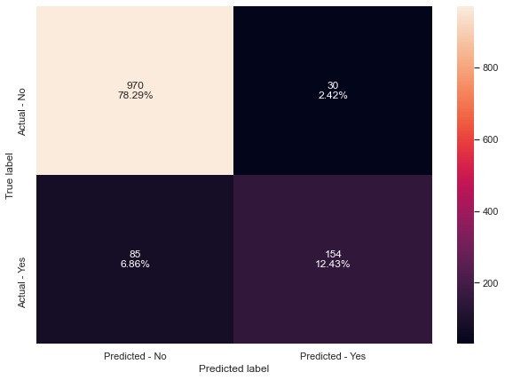

```python
# Create confusion matrix
make_confusion_matrix(bagging,y_test)
```

```python
# Create metrics
get_metrics_score(bagging)
```

```
Accuracy on training set :  0.9937694704049844
Accuracy on test set :  0.9071832122679581
Recall on training set :  0.9695340501792115
Recall on test set :  0.6443514644351465
Precision on training set :  0.9981549815498155
Precision on test set :  0.8369565217391305
F1-Score on training set :  0.9836363636363636
F1-Score on test set :  0.7281323877068557
```

```
[0.9937694704049844,
 0.9071832122679581,
 0.9695340501792115,
 0.6443514644351465,
 0.9981549815498155,
 0.8369565217391305,
 0.9836363636363636,
 0.7281323877068557]
```

#### * This tree is overfitting recall which leads to a poor F1 score

## 4.5 Bagging Classifier with weighted decision tree

#### Since this is an unbalanced data set - Let's build a weighted Bagging Classifier with 80-20 split.

```python
bagging_wt = BaggingClassifier(base_estimator=DecisionTreeClassifier(criterion='gini',class_weight={0:0.80,1:0.20},random_state=1),random_state=1)
bagging_wt.fit(X_train,y_train)
```

```
BaggingClassifier(base_estimator=DecisionTreeClassifier(class_weight={0: 0.8,
                                                                      1: 0.2},
                                                        random_state=1),
                  random_state=1)
```

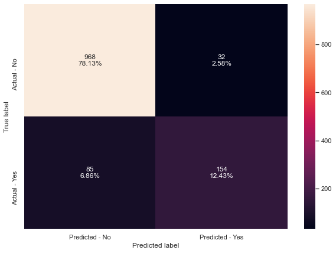

```python
# Confusion matrix
make_confusion_matrix(bagging_wt,y_test)
```

```python
# Get metrics
get_metrics_score(bagging_wt)
```

```
Accuracy on training set :  0.9948078920041536
Accuracy on test set :  0.9055690072639225
Recall on training set :  0.974910394265233
Recall on test set :  0.6443514644351465
Precision on training set :  0.998165137614679
Precision on test set :  0.8279569892473119
F1-Score on training set :  0.9864007252946511
F1-Score on test set :  0.7247058823529413
```

```
[0.9948078920041536,
 0.9055690072639225,
 0.974910394265233,
 0.6443514644351465,
 0.998165137614679,
 0.8279569892473119,
 0.9864007252946511,
 0.7247058823529413]
```